# Last Mile Logistics Auditor

## Delivery Performance Audit, Veridi Logistics

**Dataset:** Olist Brazilian E-Commerce | **Tools:** Python · Pandas · Seaborn · Matplotlib · Google Colab

> **Objective:** Audit last-mile delivery performance across Brazil to identify the root causes of negative customer reviews, focusing on geographic disparities and seasonal delay patterns.

### Key Results

- **5 Northeast states** (AL, MA, PI, CE, SE) show a critical late rate ≥15% against 5.9% in São Paulo
- **Super late deliveries** drop the average review score from **4.29 to 1.79 / 5**
- **Seasonal spikes** identified: Black Friday (14.3%) , Carnival (16.0%) and March 2018 (21.4% peak)
- Audited **96,478 delivered orders** across 27 Brazilian states

> *Note: Some abbreviations are used throughout this study for readability:*
> - *Avg : Average*
> - *AL : Alagoas*
> - *MA : Maranhão*
> - *PI : Piauí*
> - *CE : Ceará*
> - *SE : Sergipe*
> - *RO : Rondonia*
> - *SP : São Paulo*
> - *CSV : Comma-Separated Values*
> - *ZIP : Zero Information Protocol*
> - *Cols : Columns*
> - *% : Percentage*
> - *vs : Versus*
> - *PT : Portuguese*
> - *EN : English*
> - *Peak : Highest recorded value*
> - *n : Number of orders*
> - *STDERR : Standard Error*

## Data Loading

Download the dataset from **[Kaggle - Olist Brazilian E-Commerce Dataset](https://www.kaggle.com/datasets/olistbr/brazilian-ecommerce)**, extract the ZIP file, then upload the CSV files using the cell below.

**Key Files:**

- `olist_orders_dataset.csv` : Central table
- `olist_order_reviews_dataset.csv` : Customer sentiment
- `olist_customers_dataset.csv` : Customer location
- `olist_products_dataset.csv` : Product categories
- `product_category_name_translation.csv` : Category translation (Portuguese to English)

```python
import subprocess, sys
subprocess.run([sys.executable, '-m', 'pip', 'install', 'geopandas', 'requests', '--quiet'], check=False)
```

```
CompletedProcess(args=['/usr/bin/python3', '-m', 'pip', 'install', 'geopandas', 'requests', '--quiet'], returncode=0)
```

```python
import pandas as pd
import numpy as np
import matplotlib.pyplot as plt
import matplotlib.patches as mpatches
import seaborn as sns
import warnings
warnings.filterwarnings('ignore')

plt.rcParams['figure.facecolor'] = 'white'
plt.rcParams['axes.facecolor'] = '#f8f9fa'

orders      = pd.read_csv('olist_orders_dataset.csv')
reviews     = pd.read_csv('olist_order_reviews_dataset.csv')
customers   = pd.read_csv('olist_customers_dataset.csv')
products    = pd.read_csv('olist_products_dataset.csv')
translation = pd.read_csv('product_category_name_translation.csv')

print(f'  Orders:      {orders.shape[0]:,} rows × {orders.shape[1]} cols')
print(f'  Reviews:     {reviews.shape[0]:,} rows × {reviews.shape[1]} cols')
print(f'  Customers:   {customers.shape[0]:,} rows × {customers.shape[1]} cols')
print(f'  Products:    {products.shape[0]:,} rows × {products.shape[1]} cols')
print(f'  Translation: {translation.shape[0]:,} rows × {translation.shape[1]} cols')
```

```
  Orders:      99,441 rows × 8 cols
  Reviews:     99,224 rows × 7 cols
  Customers:   99,441 rows × 5 cols
  Products:    32,951 rows × 9 cols
  Translation: 71 rows × 2 cols
```

## Data Exploration

```python
for name, data in [('Orders', orders), ('Reviews', reviews),
                   ('Customers', customers), ('Products', products)]:
    print(f'\n {name} ')
    display(data.head(2))
```

[output not shown]

## Story 1: Schema Builder, Joining the Tables

**Goal:** Join Orders + Reviews + Customers into a single master dataset without duplicate rows.

```python
reviews_deduped = reviews.sort_values('review_creation_date', ascending=False)\
                          .drop_duplicates(subset='order_id', keep='first')

print(f'  Deduplication ')
print(f'  Reviews original:     {len(reviews):,}')
print(f'  Reviews deduplicated: {len(reviews_deduped):,}')
print(f'  Duplicates removed:   {len(reviews) - len(reviews_deduped):,}')

df = orders.merge(reviews_deduped, on='order_id', how='left')
df = df.merge(customers, on='customer_id', how='left')

print(f'  Master Dataset ')
print(f'  Orders original:  {len(orders):,}')
print(f'  Master dataset:   {len(df):,}')
print(f'  Duplicates check: {"No duplicates" if len(df) == len(orders) else "Duplicates detected"}')
```

```
  Deduplication
  Reviews original:     99,224
  Reviews deduplicated: 98,673
  Duplicates removed:   551
  Master Dataset
  Orders original:  99,441
  Master dataset:   99,441
  Duplicates check: No duplicates
```

```python
display(df.head(2))
```

[output not shown]

## Data Cleaning

```python
date_cols = [
    'order_purchase_timestamp',
    'order_approved_at',
    'order_delivered_carrier_date',
    'order_delivered_customer_date',
    'order_estimated_delivery_date'
]
for col in date_cols:
    df[col] = pd.to_datetime(df[col])

print(' Missing Values ')
print(df.isnull().sum())
print('\n Order Status Distribution ')
print(df['order_status'].value_counts())
```

```
 Missing Values
order_id                             0
customer_id                          0
order_status                         0
order_purchase_timestamp             0
order_approved_at                  160
order_delivered_carrier_date      1783
order_delivered_customer_date     2965
order_estimated_delivery_date        0
review_id                          768
review_score                       768
review_comment_title             87889
review_comment_message           58667
review_creation_date               768
review_answer_timestamp            768
customer_unique_id                   0
customer_zip_code_prefix             0
customer_city                        0
customer_state                       0
dtype: int64

 Order Status Distribution
order_status
delivered      96478
shipped         1107
canceled         625
unavailable      609
invoiced         314
processing       301
created            5
approved           2
Name: count, dtype: int64
```

## Story 2: Delay Calculator, Real Delivery Performance

**Formula:** Days_Difference = order_estimated_delivery_date - order_delivered_customer_date

| Value | Meaning |
| --- | --- |
| ≥ 0 days | On Time |
| -5 to 0 days | Late |
| < -5 days | Super Late |

```python
df_delivered = df[df['order_status'] == 'delivered'].copy()

df_delivered['days_difference'] = (
    df_delivered['order_estimated_delivery_date'] -
    df_delivered['order_delivered_customer_date']
).dt.days

def classify_delivery(days):
    if days >= 0:
        return 'On Time'
    elif days >= -5:
        return 'Late'
    else:
        return 'Super Late'

df_delivered['delivery_status'] = df_delivered['days_difference'].apply(classify_delivery)

total = len(df_delivered)
summary = df_delivered['delivery_status'].value_counts()

print('Delivery Performance Summary')
for status, count in summary.items():
    pct = (count / total) * 100
    print(f'  {status}: {count:,} orders ({pct:.1f}%)')

print(f'\n Total late orders: {summary.get("Late",0) + summary.get("Super Late",0):,}')
print(f' Late rate: {((summary.get("Late",0) + summary.get("Super Late",0)) / total * 100):.1f}%')
```

```
Delivery Performance Summary
  On Time: 88,644 orders (91.9%)
  Super Late: 4,219 orders (4.4%)
  Late: 3,615 orders (3.7%)

 Total late orders: 7,834
 Late rate: 8.1%
```

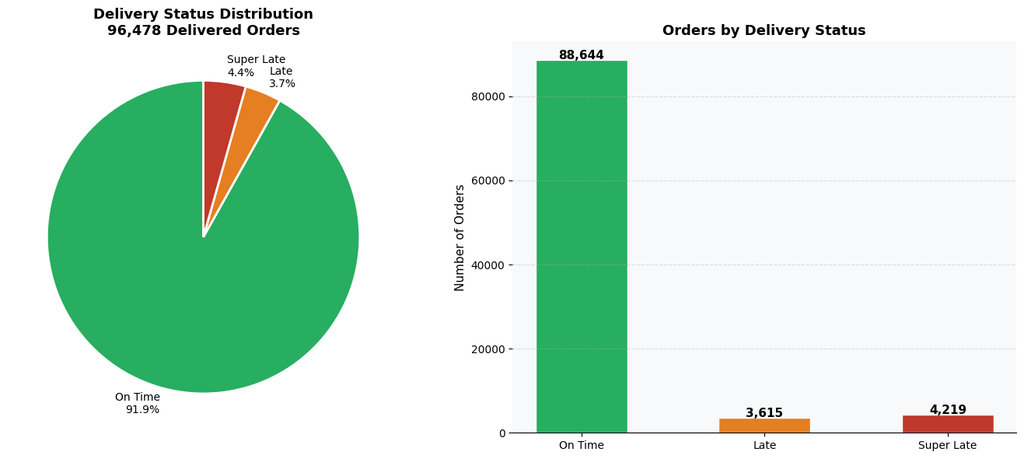

```python
fig, (ax1, ax2) = plt.subplots(1, 2, figsize=(14, 6))

pie_colors = ['#27ae60', '#e67e22', '#c0392b']
pie_data = [summary.get('On Time', 0), summary.get('Late', 0), summary.get('Super Late', 0)]
pie_labels = [
    f'On Time\n{pie_data[0]/total*100:.1f}%',
    f'Late\n{pie_data[1]/total*100:.1f}%',
    f'Super Late\n{pie_data[2]/total*100:.1f}%'
]
ax1.pie(pie_data, labels=pie_labels, colors=pie_colors,
        startangle=90, wedgeprops={'edgecolor': 'white', 'linewidth': 2})
ax1.set_title('Delivery Status Distribution\n96,478 Delivered Orders',
              fontsize=13, fontweight='bold')

statuses = ['On Time', 'Late', 'Super Late']
counts = [summary.get(s, 0) for s in statuses]
bars = ax2.bar(statuses, counts, color=pie_colors, edgecolor='white', width=0.5)
for bar, count in zip(bars, counts):
    ax2.text(bar.get_x() + bar.get_width()/2, bar.get_height() + 200,
             f'{count:,}', ha='center', fontsize=11, fontweight='bold')
ax2.set_ylabel('Number of Orders', fontsize=11)
ax2.set_title('Orders by Delivery Status', fontsize=13, fontweight='bold')
ax2.grid(axis='y', linestyle='--', alpha=0.4)
ax2.spines[['top', 'right', 'left']].set_visible(False)

plt.tight_layout()
plt.savefig('delivery_status_overview.png', dpi=150, bbox_inches='tight')
plt.show()
```

## Story 3: Geographic Analysis, Late Deliveries by State

**Goal:** Identify which Brazilian states have the highest late delivery rates.

```python
geo = df_delivered.groupby('customer_state').agg(
    total_orders=('order_id', 'count'),
    late_orders=('delivery_status', lambda x: (x != 'On Time').sum())
).reset_index()

geo['late_pct'] = (geo['late_orders'] / geo['total_orders'] * 100).round(1)
geo = geo.sort_values('late_pct', ascending=False)

print('Late Delivery % by State')
print(geo.to_string(index=False))
```

```
Late Delivery % by State
customer_state  total_orders  late_orders  late_pct
            AL           397           95      23.9
            MA           717          141      19.7
            PI           476           76      16.0
            CE          1279          196      15.3
            SE           335           51      15.2
            BA          3256          457      14.0
            RJ         12350         1664      13.5
            TO           274           35      12.8
            PA           946          117      12.4
            RR            41            5      12.2
            ES          1995          244      12.2
            MS           701           81      11.6
            PB           517           57      11.0
            PE          1593          172      10.8
            RN           474           51      10.8
            SC          3546          346       9.8
            GO          1957          160       8.2
            RS          5345          383       7.2
            DF          2080          147       7.1
            MT           886           60       6.8
            SP         40501         2394       5.9
            MG         11354          637       5.6
            PR          4923          246       5.0
            AP            67            3       4.5
            AM           145            6       4.1
            AC            80            3       3.8
            RO           243            7       2.9
```

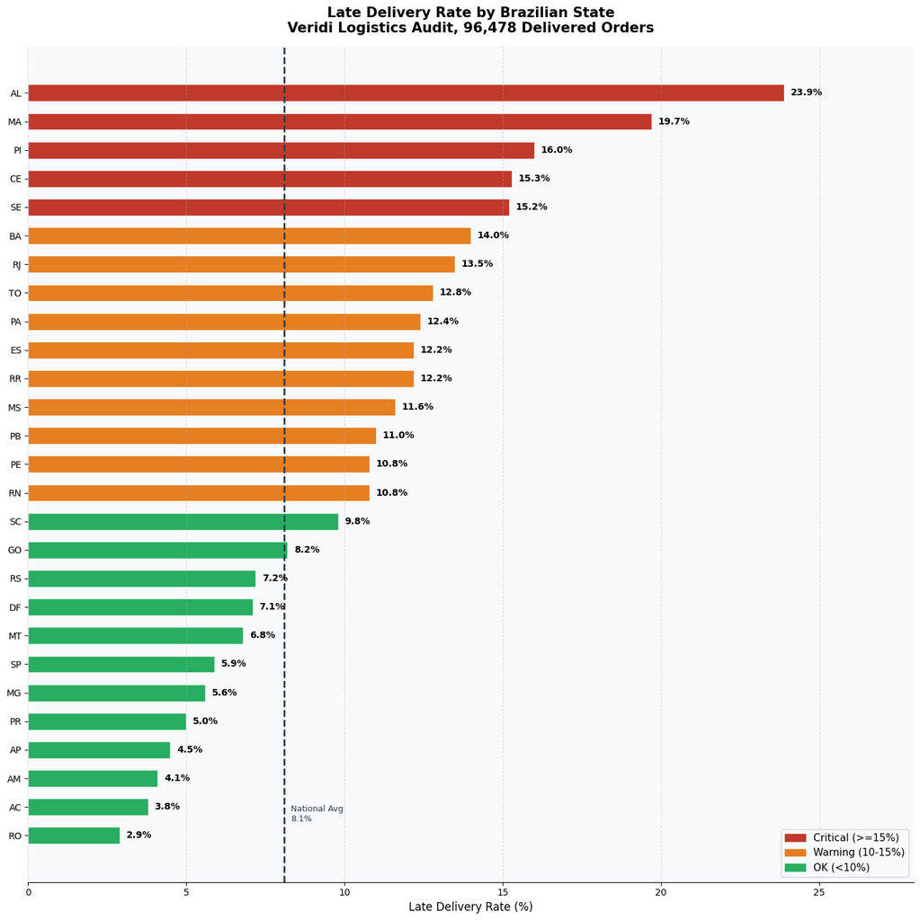

```python
geo_sorted = geo.sort_values('late_pct', ascending=True)

def get_color(pct):
    if pct >= 15: return '#c0392b'
    elif pct >= 10: return '#e67e22'
    else: return '#27ae60'

colors = geo_sorted['late_pct'].apply(get_color)

fig, ax = plt.subplots(figsize=(14, 14))
bars = ax.barh(geo_sorted['customer_state'], geo_sorted['late_pct'],
               color=colors, edgecolor='white', height=0.6)

for bar, val in zip(bars, geo_sorted['late_pct']):
    ax.text(bar.get_width() + 0.2, bar.get_y() + bar.get_height()/2,
            f'{val}%', va='center', fontsize=10, fontweight='bold')

ax.axvline(x=8.1, color='#2c3e50', linestyle='--', linewidth=2)
ax.text(8.3, 0.5, 'National Avg\n8.1%', color='#2c3e50', fontsize=9)
ax.grid(axis='x', linestyle='--', alpha=0.4)
ax.spines[['top', 'right', 'left']].set_visible(False)
ax.set_xlim(0, 28)
ax.set_xlabel('Late Delivery Rate (%)', fontsize=12)
ax.set_title('Late Delivery Rate by Brazilian State\nVeridi Logistics Audit, 96,478 Delivered Orders',
             fontsize=15, fontweight='bold', pad=15)

legend_elements = [
    mpatches.Patch(color='#c0392b', label='Critical (>=15%)'),
    mpatches.Patch(color='#e67e22', label='Warning (10-15%)'),
    mpatches.Patch(color='#27ae60', label='OK (<10%)'),
]
ax.legend(handles=legend_elements, loc='lower right', fontsize=11)

plt.tight_layout()
plt.savefig('late_delivery_by_state.png', dpi=150, bbox_inches='tight')
plt.show()
```

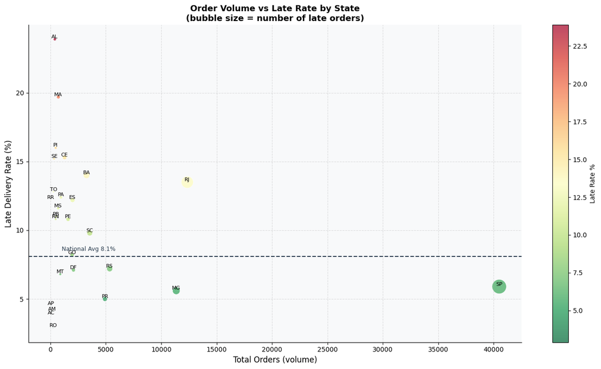

```python
fig, ax = plt.subplots(figsize=(14, 8))

scatter = ax.scatter(geo['total_orders'], geo['late_pct'],
                     s=geo['late_orders']/5,
                     c=geo['late_pct'], cmap='RdYlGn_r',
                     alpha=0.7, edgecolors='white', linewidth=0.5)

for _, row in geo.iterrows():
    ax.annotate(row['customer_state'],
                (row['total_orders'], row['late_pct']),
                fontsize=8, ha='center', va='bottom')

ax.axhline(y=8.1, color='#2c3e50', linestyle='--', linewidth=1.5)
ax.text(1000, 8.5, 'National Avg 8.1%', color='#2c3e50', fontsize=9)
ax.set_xlabel('Total Orders (volume)', fontsize=12)
ax.set_ylabel('Late Delivery Rate (%)', fontsize=12)
ax.set_title('Order Volume vs Late Rate by State\n(bubble size = number of late orders)',
             fontsize=13, fontweight='bold')
ax.grid(linestyle='--', alpha=0.4)
ax.spines[['top', 'right']].set_visible(False)
plt.colorbar(scatter, ax=ax, label='Late Rate %')

plt.tight_layout()
plt.savefig('geographic_bubble.png', dpi=150, bbox_inches='tight')
plt.show()
```

### Map : Late Delivery Rate by State

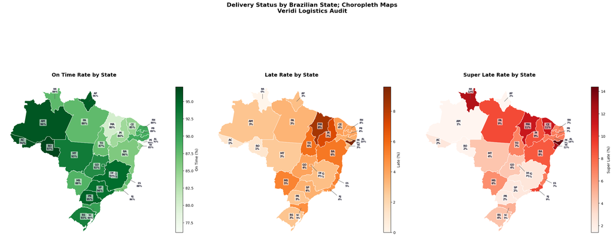

```python
import geopandas as gpd, requests, os

geojson_url  = 'https://raw.githubusercontent.com/codeforamerica/click_that_hood/master/public/data/brazil-states.geojson'
geojson_path = 'brazil_states.geojson'

if not os.path.exists(geojson_path):
    r = requests.get(geojson_url, timeout=30)
    with open(geojson_path, 'w') as f:
        f.write(r.text)
    print('GeoJSON downloaded.')

brazil = gpd.read_file(geojson_path)

sigla_map = {
    'Acre':'AC','Alagoas':'AL','Amapá':'AP','Amazonas':'AM','Bahia':'BA',
    'Ceará':'CE','Distrito Federal':'DF','Espírito Santo':'ES','Goiás':'GO',
    'Maranhão':'MA','Mato Grosso':'MT','Mato Grosso do Sul':'MS','Minas Gerais':'MG',
    'Pará':'PA','Paraíba':'PB','Paraná':'PR','Pernambuco':'PE','Piauí':'PI',
    'Rio de Janeiro':'RJ','Rio Grande do Norte':'RN','Rio Grande do Sul':'RS',
    'Rondônia':'RO','Roraima':'RR','Santa Catarina':'SC','São Paulo':'SP',
    'Sergipe':'SE','Tocantins':'TO'
}
brazil['sigla'] = brazil['name'].map(sigla_map)

geo_status = df_delivered.groupby(['customer_state', 'delivery_status']).size().unstack(fill_value=0)
geo_status['total']          = geo_status.sum(axis=1)
geo_status['on_time_pct']    = (geo_status.get('On Time',    0) / geo_status['total'] * 100).round(1)
geo_status['late_pct']       = (geo_status.get('Late',       0) / geo_status['total'] * 100).round(1)
geo_status['super_late_pct'] = (geo_status.get('Super Late', 0) / geo_status['total'] * 100).round(1)
geo_status = geo_status.reset_index()

brazil_merged = brazil.merge(geo_status, left_on='sigla', right_on='customer_state', how='left')

offsets = {
    'DF': ( 2.5, -2.5), 'SE': ( 3.0,  0.0), 'AL': ( 3.5,  0.5),
    'PB': ( 3.0,  1.0), 'RN': ( 3.0,  2.0), 'PE': ( 3.5, -1.0),
    'ES': ( 3.0, -1.5), 'RJ': ( 3.0, -2.5), 'SC': (-1.0, -2.5),
    'AP': ( 2.0,  2.0), 'RR': ( 0.0,  2.5),
}

def annotate_states(ax, brazil_merged, col):
    for _, row in brazil_merged.iterrows():
        if row.geometry is None or row['sigla'] is None:
            continue
        c   = row.geometry.centroid
        val = row.get(col, None)
        if val is None or pd.isna(val):
            continue

        label  = f"{row['sigla']}\n{val:.0f}%"
        sigla  = row['sigla']

        if sigla in offsets:
            dx, dy = offsets[sigla]
            xt, yt = c.x + dx, c.y + dy
            ax.annotate(
                label,
                xy=(c.x, c.y), xytext=(xt, yt),
                ha='center', va='center',
                fontsize=6.5, fontweight='bold', color='#1a1a2e',
                arrowprops=dict(arrowstyle='-', color='#555555', lw=0.8),
                bbox=dict(boxstyle='round,pad=0.2', fc='white', ec='none', alpha=0.7)
            )
        else:
            ax.annotate(
                label,
                xy=(c.x, c.y),
                ha='center', va='center',
                fontsize=7, fontweight='bold', color='#1a1a2e',
                bbox=dict(boxstyle='round,pad=0.2', fc='white', ec='none', alpha=0.6)
            )

fig, axes = plt.subplots(1, 3, figsize=(24, 11))

configs = [
    ('on_time_pct',    'On Time (%)',     'Greens',  'On Time Rate by State'),
    ('late_pct',       'Late (%)',        'Oranges', 'Late Rate by State'),
    ('super_late_pct', 'Super Late (%)' , 'Reds',    'Super Late Rate by State'),
]

for ax, (col, label, cmap, title) in zip(axes, configs):
    brazil_merged.plot(
        column=col, ax=ax, cmap=cmap, legend=True,
        legend_kwds={'label': label, 'shrink': 0.55, 'orientation': 'vertical'},
        edgecolor='white', linewidth=0.6,
        missing_kwds={'color': '#eeeeee'}
    )
    annotate_states(ax, brazil_merged, col)
    ax.set_axis_off()
    ax.set_title(title, fontsize=14, fontweight='bold', pad=12)

plt.suptitle('Delivery Status by Brazilian State; Choropleth Maps\nVeridi Logistics Audit',
             fontsize=16, fontweight='bold', y=1.02)
plt.tight_layout()
plt.savefig('choropleth_map.png', dpi=150, bbox_inches='tight')
plt.show()
```

## Story 4: Sentiment Analysis, Delay vs Review Score

**Goal:** Prove that late deliveries directly cause bad customer reviews.

```python
sentiment = df_delivered.groupby('delivery_status')['review_score'].mean().round(2)
print('Average Review Score by Delivery Status')
print(sentiment)
```

```
Average Review Score by Delivery Status
delivery_status
Late          3.46
On Time       4.29
Super Late    1.79
Name: review_score, dtype: float64
```

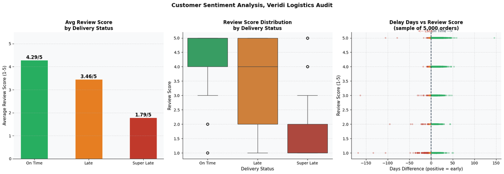

```python
fig, axes = plt.subplots(1, 3, figsize=(18, 6))
ax1 = axes[0]
statuses = ['On Time', 'Late', 'Super Late']
scores = [4.29, 3.46, 1.79]
bar_colors = ['#27ae60', '#e67e22', '#c0392b']
bars = ax1.bar(statuses, scores, color=bar_colors, width=0.5, edgecolor='white')
for bar, val in zip(bars, scores):
    ax1.text(bar.get_x() + bar.get_width()/2, bar.get_height() + 0.05,
             f'{val}/5', ha='center', fontsize=12, fontweight='bold')
ax1.set_ylim(0, 5.5)
ax1.set_ylabel('Average Review Score (1-5)', fontsize=11)
ax1.set_title('Avg Review Score\nby Delivery Status', fontsize=12, fontweight='bold')
ax1.grid(axis='y', linestyle='--', alpha=0.4)
ax1.spines[['top', 'right', 'left']].set_visible(False)

ax2 = axes[1]
order = ['On Time', 'Late', 'Super Late']
palette = {'On Time': '#27ae60', 'Late': '#e67e22', 'Super Late': '#c0392b'}
sns.boxplot(x='delivery_status', y='review_score', data=df_delivered,
            order=order, palette=palette, ax=ax2)
ax2.set_xlabel('Delivery Status', fontsize=11)
ax2.set_ylabel('Review Score', fontsize=11)
ax2.set_title('Review Score Distribution\nby Delivery Status', fontsize=12, fontweight='bold')
ax2.grid(axis='y', linestyle='--', alpha=0.4)
ax2.spines[['top', 'right']].set_visible(False)

ax3 = axes[2]
sample = df_delivered.sample(n=5000, random_state=42)
scatter_colors = sample['delivery_status'].map(
    {'On Time': '#27ae60', 'Late': '#e67e22', 'Super Late': '#c0392b'})
ax3.scatter(sample['days_difference'], sample['review_score'],
            c=scatter_colors, alpha=0.3, s=10)
ax3.axvline(x=0, color='#2c3e50', linestyle='--', linewidth=1.5)
ax3.text(1, 5.2, 'On Time -->', color='#2c3e50', fontsize=9)
ax3.text(-30, 5.2, '<-- Late', color='#c0392b', fontsize=9)
ax3.set_xlabel('Days Difference (positive = early)', fontsize=11)
ax3.set_ylabel('Review Score (1-5)', fontsize=11)
ax3.set_title('Delay Days vs Review Score\n(sample of 5,000 orders)', fontsize=12, fontweight='bold')
ax3.grid(linestyle='--', alpha=0.4)
ax3.spines[['top', 'right']].set_visible(False)

plt.suptitle('Customer Sentiment Analysis, Veridi Logistics Audit',
             fontsize=14, fontweight='bold', y=1.02)
plt.tight_layout()
plt.savefig('sentiment_analysis.png', dpi=150, bbox_inches='tight')
plt.show()
```

## Bonus: Product Category Translation (PT to EN)

```python
products_en = products.merge(translation, on='product_category_name', how='left')
print(f'  Product Category Translation (PT → EN) ')
print(f'  Translated: {products_en["product_category_name_english"].notna().sum():,} categories')
print(f'  Missing:    {products_en["product_category_name_english"].isna().sum():,} categories')
```

```
  Product Category Translation (PT → EN)
  Translated: 32,328 categories
  Missing:    623 categories
```

## Candidate's Choice 1: Seasonality Analysis

**Business Value:** Identifying seasonal patterns allows Veridi Logistics to proactively allocate resources during high-risk months such as Black Friday and Carnival to prevent delay spikes before they happen.

```python
df_delivered['purchase_month'] = df_delivered['order_purchase_timestamp'].dt.to_period('M')

seasonality = df_delivered.groupby('purchase_month').agg(
    total_orders=('order_id', 'count'),
    late_orders=('delivery_status', lambda x: (x != 'On Time').sum())
).reset_index()

seasonality['late_pct'] = (seasonality['late_orders'] / seasonality['total_orders'] * 100).round(1)
seasonality['purchase_month'] = seasonality['purchase_month'].astype(str)
seasonality_clean = seasonality[seasonality['total_orders'] >= 100].copy()

print('Seasonality: Late Rate by Month')
print(seasonality_clean.to_string(index=False))
```

```
Seasonality: Late Rate by Month
purchase_month  total_orders  late_orders  late_pct
       2016-10           265            3       1.1
       2017-01           750           23       3.1
       2017-02          1653           53       3.2
       2017-03          2546          142       5.6
       2017-04          2303          181       7.9
       2017-05          3546          129       3.6
       2017-06          3135          121       3.9
       2017-07          3872          133       3.4
       2017-08          4193          139       3.3
       2017-09          4150          216       5.2
       2017-10          4478          237       5.3
       2017-11          7289         1044      14.3
       2017-12          5513          462       8.4
       2018-01          7069          464       6.6
       2018-02          6555         1048      16.0
       2018-03          7003         1496      21.4
       2018-04          6798          361       5.3
       2018-05          6749          556       8.2
       2018-06          6099           86       1.4
       2018-07          6159          279       4.5
       2018-08          6351          660      10.4
```

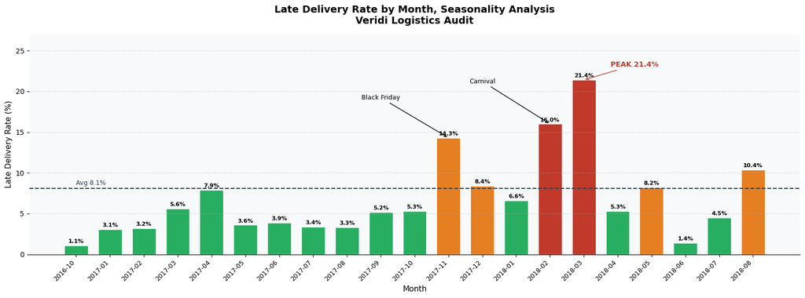

```python
fig, ax = plt.subplots(figsize=(16, 6))

colors = ['#c0392b' if x >= 15 else '#e67e22' if x >= 8 else '#27ae60'
          for x in seasonality_clean['late_pct']]

bars = ax.bar(range(len(seasonality_clean)), seasonality_clean['late_pct'],
              color=colors, edgecolor='white', width=0.7)

for bar, val in zip(bars, seasonality_clean['late_pct']):
    ax.text(bar.get_x() + bar.get_width()/2, bar.get_height() + 0.3,
            f'{val}%', ha='center', fontsize=8, fontweight='bold')

ax.set_xticks(range(len(seasonality_clean)))
ax.set_xticklabels(seasonality_clean['purchase_month'], rotation=45, ha='right', fontsize=9)

ax.axhline(y=8.1, color='#2c3e50', linestyle='--', linewidth=1.5)
ax.text(0, 8.5, 'Avg 8.1%', color='#2c3e50', fontsize=9)

months = list(seasonality_clean['purchase_month'])
idx_nov17 = months.index('2017-11')
idx_feb18 = months.index('2018-02')
idx_mar18 = months.index('2018-03')

ax.annotate('Black Friday', xy=(idx_nov17, 14.3), xytext=(idx_nov17-2, 19),
            arrowprops=dict(arrowstyle='->', color='black'), fontsize=9, ha='center')
ax.annotate('Carnival', xy=(idx_feb18, 16.0), xytext=(idx_feb18-2, 21),
            arrowprops=dict(arrowstyle='->', color='black'), fontsize=9, ha='center')
ax.annotate('PEAK 21.4%', xy=(idx_mar18, 21.4), xytext=(idx_mar18+1.5, 23),
            arrowprops=dict(arrowstyle='->', color='#c0392b'), fontsize=10,
            color='#c0392b', fontweight='bold', ha='center')

ax.grid(axis='y', linestyle='--', alpha=0.4)
ax.spines[['top', 'right', 'left']].set_visible(False)
ax.set_ylim(0, 27)
ax.set_xlabel('Month', fontsize=11)
ax.set_ylabel('Late Delivery Rate (%)', fontsize=11)
ax.set_title('Late Delivery Rate by Month, Seasonality Analysis\nVeridi Logistics Audit',
             fontsize=14, fontweight='bold', pad=15)

plt.tight_layout()
plt.savefig('seasonality_analysis.png', dpi=150, bbox_inches='tight')
plt.show()
```

## Candidate's Choice 2: Review Score Distribution Deep Dive

**Business Value:** Understanding the full distribution of review scores reveals the severity of customer dissatisfaction and helps prioritize which delay threshold needs urgent action.

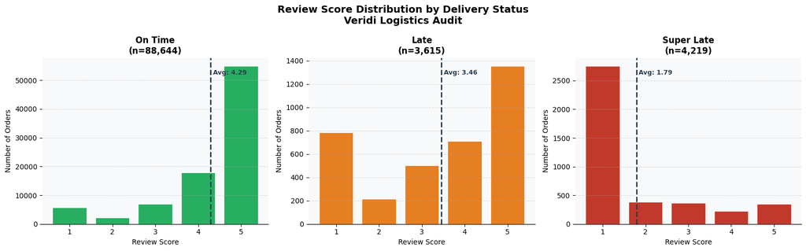

```python
fig, axes = plt.subplots(1, 3, figsize=(16, 5))

statuses = ['On Time', 'Late', 'Super Late']
colors_map = {'On Time': '#27ae60', 'Late': '#e67e22', 'Super Late': '#c0392b'}

for i, status in enumerate(statuses):
    data = df_delivered[df_delivered['delivery_status'] == status]['review_score']
    score_counts = data.value_counts().sort_index()
    axes[i].bar(score_counts.index, score_counts.values,
                color=colors_map[status], edgecolor='white')
    axes[i].set_title(f'{status}\n(n={len(data):,})', fontsize=12, fontweight='bold')
    axes[i].set_xlabel('Review Score', fontsize=10)
    axes[i].set_ylabel('Number of Orders', fontsize=10)
    axes[i].set_xticks([1, 2, 3, 4, 5])
    axes[i].grid(axis='y', linestyle='--', alpha=0.4)
    axes[i].spines[['top', 'right', 'left']].set_visible(False)
    avg = data.mean()
    axes[i].axvline(x=avg, color='#2c3e50', linestyle='--', linewidth=2)
    axes[i].text(avg+0.05, axes[i].get_ylim()[1]*0.9,
                 f'Avg: {avg:.2f}', color='#2c3e50', fontsize=9, fontweight='bold')

plt.suptitle('Review Score Distribution by Delivery Status\nVeridi Logistics Audit',
             fontsize=14, fontweight='bold')
plt.tight_layout()
plt.savefig('review_distribution.png', dpi=150, bbox_inches='tight')
plt.show()
```

## Key Findings Summary

| Metric | Value |
| --- | --- |
| Total Delivered Orders | 96,478 |
| On Time Rate | 91.9% |
| Late Rate | 8.1% (7,834 orders) |
| Worst State | AL, Alagoas (23.9% late) |
| Best State | RO, Rondonia (2.9% late) |
| Avg Review (On Time) | 4.29 / 5 |
| Avg Review (Late) | 3.46 / 5 |
| Avg Review (Super Late) | 1.79 / 5 |
| Peak Late Month | March 2018 (21.4%) |
| Critical States (>=15%) | AL, MA, PI, CE, SE |

```python
from google.colab import drive
drive.mount('/content/drive')
```

```python
import subprocess
from google.colab import files

notebook_path = "/content/drive/MyDrive/Colab Notebooks/Amalitech_Test.ipynb"

result = subprocess.run([
    "jupyter", "nbconvert",
    "--to", "html",
    "--embed-images",
    notebook_path,
    "--output-dir", "/content/"
], capture_output=True, text=True)

print("STDERR:", result.stderr)
print("Return code:", result.returncode)

files.download("/content/Amalitech_Test.html")
```

```
STDERR: [NbConvertApp] Converting notebook /content/drive/MyDrive/Colab Notebooks/Amalitech_Test.ipynb to html
[NbConvertApp] WARNING | Alternative text is missing on 7 image(s).
[NbConvertApp] Writing 1439164 bytes to /content/Amalitech_Test.html

Return code: 0
```